# 14 Playground – Interactions with manual contrasts, pairwise comparisons

```r
library(tidyverse)
library(emmeans)
# library(interactions)

hosp <- read_csv("../../data/hospital.csv") |>
  mutate(
    Treatment = case_when(
      Treatment == 'TreatA' ~ 'Meds',
      Treatment == 'TreatB' ~ 'EMDR',
      Treatment == 'TreatC' ~ 'CBT',
    ),
    Treatment = factor(Treatment),
    Hospital = factor(Hospital),
  )

# get group means
mean_Meds_1 <- mean(filter(hosp, Treatment == 'Meds', Hospital == 'Hosp1')$SWB)
mean_EMDR_1 <- mean(filter(hosp, Treatment == 'EMDR', Hospital == 'Hosp1')$SWB)
mean_CBT_1  <- mean(filter(hosp, Treatment == 'CBT',  Hospital == 'Hosp1')$SWB)
mean_Meds_2 <- mean(filter(hosp, Treatment == 'Meds', Hospital == 'Hosp2')$SWB)
mean_EMDR_2 <- mean(filter(hosp, Treatment == 'EMDR', Hospital == 'Hosp2')$SWB)
mean_CBT_2  <- mean(filter(hosp, Treatment == 'CBT',  Hospital == 'Hosp2')$SWB)
```

# Plot the data

Story: different ways of treating patients with depression.

A = antidepressants B = EMDR C = CBT

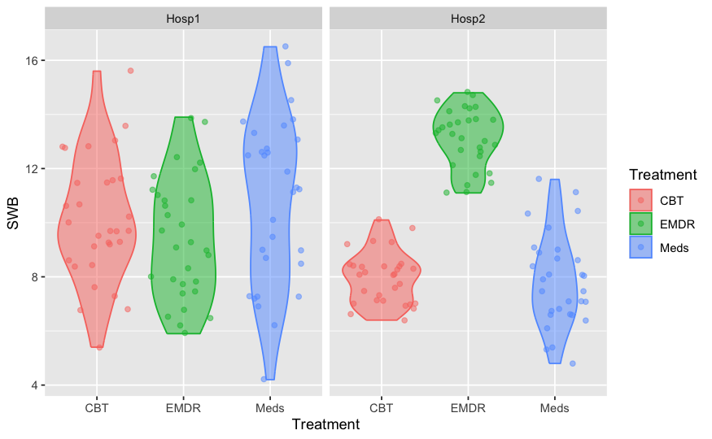

```r
hosp |>
  ggplot(aes(x = Treatment, y = SWB, colour = Treatment, fill = Treatment)) +
  geom_violin(alpha = 0.5) +
  geom_jitter(alpha = 0.5) +
  facet_wrap(~ Hospital)
```

# Fit model

```r
m1 <- lm(SWB ~ Treatment * Hospital, data = hosp)
```

# Manual post-hoc contrasts and interactions

We want to know whether there’s a difference in how effective talk therapies vs. medications are, across the two hospitals.

- CBT and EMDR vs. Meds

## Plot the contrast we want to test

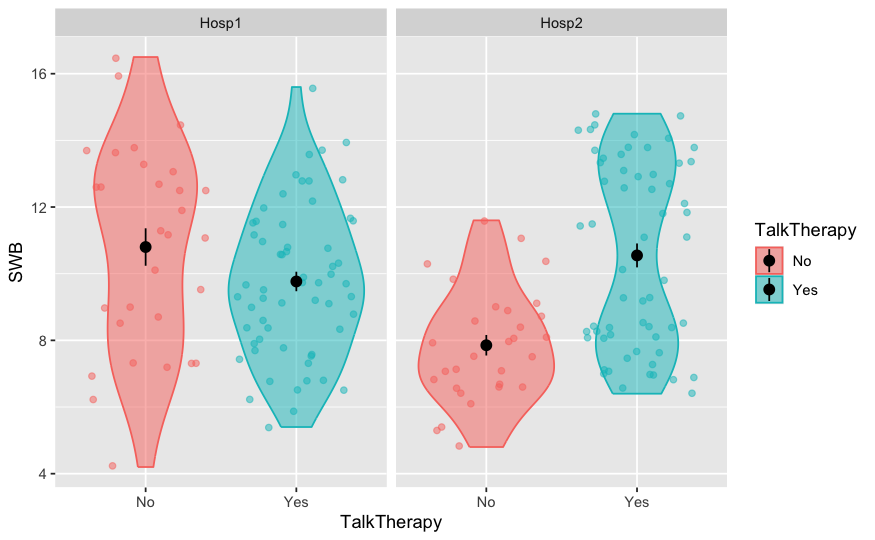

```r
hosp |>
  mutate(
    TalkTherapy = ifelse(
      Treatment == 'Meds',
      'No',
      'Yes'
    )
  ) |>
  ggplot(aes(x = TalkTherapy, y = SWB, colour = TalkTherapy, fill = TalkTherapy)) +
  geom_violin(alpha = 0.5) +
  geom_jitter(alpha = 0.5) +
  facet_wrap(~ Hospital) +
  stat_summary(geom = 'pointrange', colour = 'black') +
  NULL
```

## Get estimated marginal means

```r
m1_emm <- emmeans(m1, ~Treatment * Hospital)
m1_emm
```

```
 Treatment Hospital emmean   SE  df lower.CL upper.CL
 CBT       Hosp1     10.10 0.37 174     9.37    10.83
 EMDR      Hosp1      9.43 0.37 174     8.70    10.16
 Meds      Hosp1     10.80 0.37 174    10.07    11.53
 CBT       Hosp2      7.98 0.37 174     7.25     8.71
 EMDR      Hosp2     13.12 0.37 174    12.39    13.85
 Meds      Hosp2      7.85 0.37 174     7.12     8.58

Confidence level used: 0.95
```

## Create manual contrasts

Step 1: Create manual contrasts for each of the things we want to compare.

Step by step from before, end up with

```r
TherapyType_contr <- c(
  'CBT'  = 1/2,
  'EMDR' = 1/2,
  'Meds' = -1
)

Hosp_contr <- c(
  'Hosp1' = 1,
  'Hosp2' = -1
)
```

Step 2: To get the correct contrast coding for the interaction, combine these two predictors by getting the “outer product”. The column that appears first in the `emmeans()` table should be first in this list.

(IRL fill in matrix cell by cell, so students see where the numbers come from)

```r
ixn_contrast <- outer(TherapyType_contr, Hosp_contr)
ixn_contrast
```

```
     Hosp1 Hosp2
CBT    0.5  -0.5
EMDR   0.5  -0.5
Meds  -1.0   1.0
```

We need this in a single list of numbers in the same order as the emmeans table. Because the first emmeans col came first in the outer product, we can just use `as.vector()` to flatten the matrix, and it will be in the right order.

```r
ixn_contrast |> as.vector()
```

```
[1]  0.5  0.5 -1.0 -0.5 -0.5  1.0
```

```r
ixn_comp <- list(
  "Treat:Hosp" =
    c(
       -0.5,       # CBT  Hosp1
       -0.5,       # EMDR Hosp1
          1,       # Meds Hosp1
        0.5,       # CBT  Hosp2
        0.5,       # EMDR Hosp2
         -1        # Meds Hosp2
    )
)
```

Test the contrast using `contrast()` from emmeans.

```r
ixn_contrast_test <- contrast(m1_emm, ixn_comp)
ixn_contrast_test
```

```
 contrast   estimate    SE  df t.ratio p.value
 Treat:Hosp     3.73 0.641 174   5.819 <0.0001
```

- We can reject the H0 that there’s no difference between hospitals in the effectiveness of talk therapies vs. medication.
- Symmetrically, we can reject the H0 that the relationship between talk therapies vs. medication is the same in both hospitals.

Where does this number 3.73 come from?

```r
ixn_contrast
```

```
     Hosp1 Hosp2
CBT    0.5  -0.5
EMDR   0.5  -0.5
Meds  -1.0   1.0
```

```r
1 * mean_Meds_1 +
  -1   * mean_Meds_2 +
  -0.5 * mean_EMDR_1 +
   0.5 * mean_EMDR_2 +
  -0.5 * mean_CBT_1 +
   0.5 * mean_CBT_2
```

```
[1] 3.728333
```

It’s positive, so that means that the means that received positive weights are bigger than the means that received negative weights.

# Multiple comparisons

## get pairwise comparisons with emmeans

(By default, Tukey adjustment)

## No adjustment

```r
pair_comp <- pairs(m1_emm, adjust = 'none')

#examine output
pair_comp
```

```
 contrast                estimate    SE  df t.ratio p.value
 CBT Hosp1 - EMDR Hosp1     0.673 0.523 174   1.287  0.1998
 CBT Hosp1 - Meds Hosp1    -0.697 0.523 174  -1.332  0.1847
 CBT Hosp1 - CBT Hosp2      2.123 0.523 174   4.059 <0.0001
 CBT Hosp1 - EMDR Hosp2    -3.013 0.523 174  -5.760 <0.0001
 CBT Hosp1 - Meds Hosp2     2.250 0.523 174   4.301 <0.0001
 EMDR Hosp1 - Meds Hosp1   -1.370 0.523 174  -2.619  0.0096
 EMDR Hosp1 - CBT Hosp2     1.450 0.523 174   2.772  0.0062
 EMDR Hosp1 - EMDR Hosp2   -3.687 0.523 174  -7.047 <0.0001
 EMDR Hosp1 - Meds Hosp2    1.577 0.523 174   3.014  0.0030
 Meds Hosp1 - CBT Hosp2     2.820 0.523 174   5.390 <0.0001
 Meds Hosp1 - EMDR Hosp2   -2.317 0.523 174  -4.428 <0.0001
 Meds Hosp1 - Meds Hosp2    2.947 0.523 174   5.632 <0.0001
 CBT Hosp2 - EMDR Hosp2    -5.137 0.523 174  -9.819 <0.0001
 CBT Hosp2 - Meds Hosp2     0.127 0.523 174   0.242  0.8090
 EMDR Hosp2 - Meds Hosp2    5.263 0.523 174  10.061 <0.0001
```

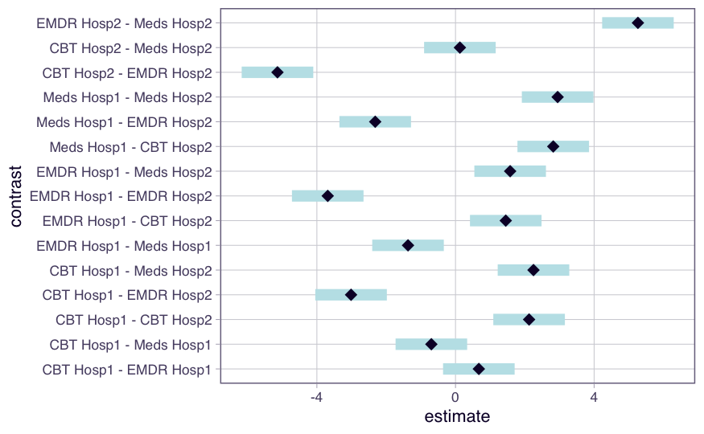

```r
plot(pair_comp)
```

## Bonferroni

```r
pair_comp <- pairs(m1_emm, adjust = 'bonferroni')

#examine output
pair_comp
```

```
 contrast                estimate    SE  df t.ratio p.value
 CBT Hosp1 - EMDR Hosp1     0.673 0.523 174   1.287  1.0000
 CBT Hosp1 - Meds Hosp1    -0.697 0.523 174  -1.332  1.0000
 CBT Hosp1 - CBT Hosp2      2.123 0.523 174   4.059  0.0011
 CBT Hosp1 - EMDR Hosp2    -3.013 0.523 174  -5.760 <0.0001
 CBT Hosp1 - Meds Hosp2     2.250 0.523 174   4.301  0.0004
 EMDR Hosp1 - Meds Hosp1   -1.370 0.523 174  -2.619  0.1441
 EMDR Hosp1 - CBT Hosp2     1.450 0.523 174   2.772  0.0928
 EMDR Hosp1 - EMDR Hosp2   -3.687 0.523 174  -7.047 <0.0001
 EMDR Hosp1 - Meds Hosp2    1.577 0.523 174   3.014  0.0445
 Meds Hosp1 - CBT Hosp2     2.820 0.523 174   5.390 <0.0001
 Meds Hosp1 - EMDR Hosp2   -2.317 0.523 174  -4.428  0.0003
 Meds Hosp1 - Meds Hosp2    2.947 0.523 174   5.632 <0.0001
 CBT Hosp2 - EMDR Hosp2    -5.137 0.523 174  -9.819 <0.0001
 CBT Hosp2 - Meds Hosp2     0.127 0.523 174   0.242  1.0000
 EMDR Hosp2 - Meds Hosp2    5.263 0.523 174  10.061 <0.0001

P value adjustment: bonferroni method for 15 tests
```

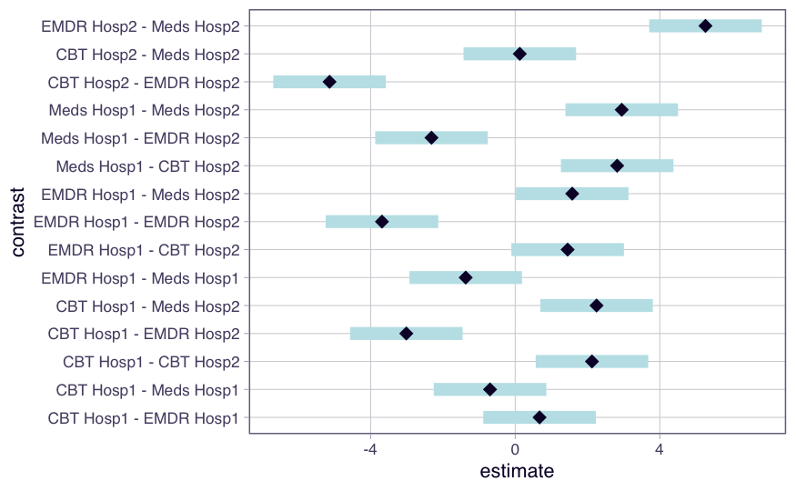

```r
plot(pair_comp)
```

## Tukey

```r
pair_comp <- pairs(m1_emm, adjust = 'tukey')

#examine output
pair_comp
```

```
 contrast                estimate    SE  df t.ratio p.value
 CBT Hosp1 - EMDR Hosp1     0.673 0.523 174   1.287  0.7918
 CBT Hosp1 - Meds Hosp1    -0.697 0.523 174  -1.332  0.7670
 CBT Hosp1 - CBT Hosp2      2.123 0.523 174   4.059  0.0010
 CBT Hosp1 - EMDR Hosp2    -3.013 0.523 174  -5.760 <0.0001
 CBT Hosp1 - Meds Hosp2     2.250 0.523 174   4.301  0.0004
 EMDR Hosp1 - Meds Hosp1   -1.370 0.523 174  -2.619  0.0982
 EMDR Hosp1 - CBT Hosp2     1.450 0.523 174   2.772  0.0670
 EMDR Hosp1 - EMDR Hosp2   -3.687 0.523 174  -7.047 <0.0001
 EMDR Hosp1 - Meds Hosp2    1.577 0.523 174   3.014  0.0346
 Meds Hosp1 - CBT Hosp2     2.820 0.523 174   5.390 <0.0001
 Meds Hosp1 - EMDR Hosp2   -2.317 0.523 174  -4.428  0.0002
 Meds Hosp1 - Meds Hosp2    2.947 0.523 174   5.632 <0.0001
 CBT Hosp2 - EMDR Hosp2    -5.137 0.523 174  -9.819 <0.0001
 CBT Hosp2 - Meds Hosp2     0.127 0.523 174   0.242  0.9999
 EMDR Hosp2 - Meds Hosp2    5.263 0.523 174  10.061 <0.0001

P value adjustment: tukey method for comparing a family of 6 estimates
```

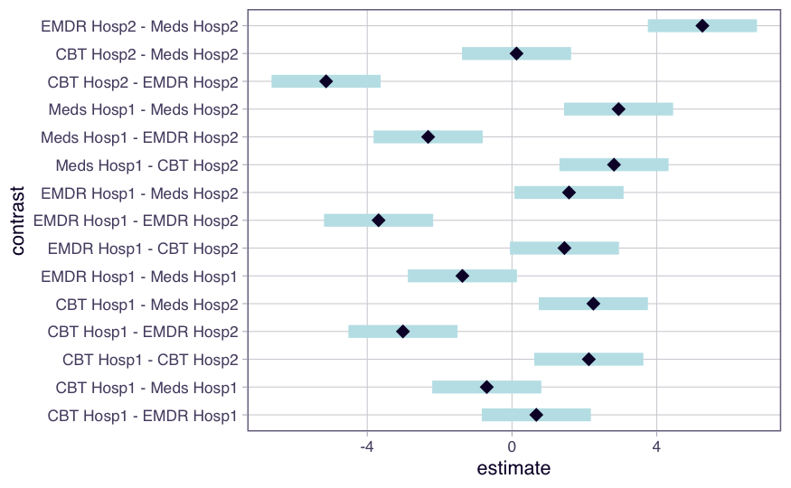

```r
plot(pair_comp)
```

## Editorialising

Why do I think this is not a great thing to do? It encourages poor scientific practice like HARKing (Hypothesising After Results are Known).